Final Project 2: COVID19 Data Analysis Binyam M. Shiferaw **Last updated on:** Mon, Mar 06 2023

# Data Analysis on Covid-19 data from John Hopkins

## Data Sources

The data source is the COVID-19 Data Repository by Johns Hopkins University’s Center for Systems Science and Engineering (CSSE). The repository presents data sets on US and global confirmed cases and confirmed deaths, with an additional list on global recovery.

The Center for Systems Science and Engineering (CSSE) is a research collective housed within the Department of Civil and Systems Engineering (CaSE) at Johns Hopkins University (JHU). The faculty, researchers, and students work on complex and interdisciplinary problems, united by the goal of better understanding and improving societal, health, and technological systems for everyone (https://systems.jhu.edu/).

- https://github.com/CSSEGISandData/COVID-19/tree/master/csse_covid_19_data/csse_covid_19_time_series

To perform continent wise analysis, we will use the ISO countries with Regional Code look up table:

- https://github.com/lukes/ISO-3166-Countries-with-Regional-Codes/blob/master/all/all.csv

The model uses age data for all countries to assess the link between how young the population of a country is and covid cases and deaths. However, since the data cannot be imported directly from the Our World in Data website, it was downloaded to the same folder as the rmd file for analysis(I have uploaded the CSV file to github with the RMD file for reproducibility)

- Global median age by country
  - https://ourworldindata.org/age-structure

## Review Objective and Questions

NOTE: I have left the R-code (i.e., Echo set to TRUE by default) as part of the report to make reviewing the analysis easier for my peers.

There have been reports that the pandemic’s impact in Africa remains markedly lower compared to the Americas, Europe, and Asia. The main objective of this review is to assess if the data support such an observation and if the age of the population could be one factor in the lower impact of the pandemic. More specifically, the review tried to tackle the following questions:

1. Did Africa have a lower number of COVID-19 cases compared to the Americas, Europe, and Asia?
2. Did Africa have a lower number of deaths per number of confirmed cases compared to the Americas, Europe, and Asia?
3. Is there difference in number of confirmed cases of COVID-19 among African countries?
4. MODEL: Does country’s population median age predict the number of confirmed COVID-19 cases and deaths in a country?

## Environment Set-up, Analysis and Visualization Process

### 1). R libraries set-up

**The following libraries required to reproduce the analysis and results. “prettydoc” was used for html formatting!**

- Data visualization
  - ggplot2
  - patchwork
- Data wrangling
  - tidyverse
  - lubridate
- R markdown and output formatting
  - prettydoc
  - rmarkdown
  - knit

```r
# Import libraries
library(knitr)
library(rmarkdown)
library(tidyverse)
library(lubridate)
library(ggplot2)
library(prettydoc)
library(patchwork)
```

### 2). Import and loading data

*Importing global data only, although the repo provides separate data on the US*

```r
# URL set-up
url_in <- "https://raw.githubusercontent.com/CSSEGISandData/COVID-19/master/csse_covid_19_data/csse_covid_19_time_series/"
filenames <- c("time_series_covid19_confirmed_global.csv", "time_series_covid19_deaths_global.csv", "time_series_covid19_recovered_global.csv")
urls <- str_c(url_in, filenames)

# Import COVID-19 data
global_cases <- read_csv(urls[1])
global_deaths <- read_csv(urls[2])
global_recovered <- read_csv(urls[3])

#Import UID data from CSSE to be used as a transition to add Region/Continent
uid_lookup_url <- 'https://raw.githubusercontent.com/CSSEGISandData/COVID-19/master/csse_covid_19_data/UID_ISO_FIPS_LookUp_Table.csv'
uid <- read_csv(uid_lookup_url) %>% select(-c(Lat, Long_, Combined_Key, code3, Admin2))

# Import region look-up table to add Region/Continent to the data set
region_lookup_url <- "https://raw.githubusercontent.com/lukes/ISO-3166-Countries-with-Regional-Codes/master/all/all.csv"

uid_region <- read_csv(region_lookup_url)

# Import median age data for use in model
median_age <- read.csv("median-age.csv")
```

### 3). Tidy and transform data

```r
# Step 1: PIVOT TABLES - Global Cases and Global Deaths: with 'Province/State' and 'Country/Region' as factors, and pivot dates as rows
global_cases <- mutate_at(global_cases, vars('Province/State', 'Country/Region'), as.factor) %>%    pivot_longer(cols = -c('Province/State', 'Country/Region', 'Lat', 'Long'), names_to = 'Date', values_to = 'Cases') %>% select(-c('Lat', 'Long'))


global_deaths <- mutate_at(global_deaths, vars('Province/State', 'Country/Region'), as.factor) %>% pivot_longer(cols = -c('Province/State', 'Country/Region', 'Lat', 'Long'), names_to = 'Date', values_to = 'Deaths') %>% select(-c('Lat', 'Long'))

# Step 2: Merge global_cases and global_deaths into one global data frame, and mutate "Date" field into a date object
global <- global_cases %>% full_join(global_deaths) %>% mutate(Date = mdy(Date))

# Step 3: View the first few rows for validation
head(global)
```

```
## # A tibble: 6 x 5
##   `Province/State` `Country/Region` Date       Cases Deaths
##   <fct>            <fct>            <date>     <dbl>  <dbl>
## 1 <NA>             Afghanistan      2020-01-22     0      0
## 2 <NA>             Afghanistan      2020-01-23     0      0
## 3 <NA>             Afghanistan      2020-01-24     0      0
## 4 <NA>             Afghanistan      2020-01-25     0      0
## 5 <NA>             Afghanistan      2020-01-26     0      0
## 6 <NA>             Afghanistan      2020-01-27     0      0
```

```r
# Step 4: Rename column for ease of reference and create a combined key column to be used for merging
global <- global %>% rename(Country_Region = 'Country/Region', Province_State = 'Province/State') %>% unite('Combined_Key', c(Province_State, Country_Region), sep = ', ', na.rm = TRUE, remove = FALSE)


# Step 5: Join 'global' uid look up table and select only needed columns
global <- global %>% left_join(uid, by = c('Province_State', 'Country_Region')) %>% select(-c(UID, FIPS)) %>% select(Province_State, Country_Region, Date, Cases, Deaths, Population, Combined_Key, iso2, iso3)

# Step 6: Get continent from region look up df, and rename the name column to country
uid_region <- uid_region %>% select(c(name, region, "alpha-2", "alpha-3")) %>% rename(Country = "name", iso2 = "alpha-2", iso3 = "alpha-3")

# Step 7: Merge global and regional look up data based on ISO keys
global <- global %>% left_join(uid_region, by = c("iso2", "iso3"))

# step 8: get the 2020 median age of all countries and merge with the global df from step 7. 2020 was chosen to capture the population structure when the pandemic started
median_age <- median_age %>% filter(Year == "2020") %>% rename(iso3 = "Code")

global <- global  %>% left_join(median_age, by = c("iso3"))

head(median_age)
```

```
##           Entity iso3 Year Median_Age
## 1    Afghanistan  AFG 2020       16.6
## 2    Africa (UN)      2020       18.6
## 3        Albania  ALB 2020       36.9
## 4        Algeria  DZA 2020       27.6
## 5 American Samoa  ASM 2020       26.9
## 6        Andorra  AND 2020       42.1
```

```r
# # Step 9: With merging complete, remove columns used for the role
global <- global %>% select(-c(Province_State, iso2, iso3, Combined_Key, Country)) %>% rename(Country = "Country_Region", Region = "region")


head(global)
```

```
## # A tibble: 6 x 9
##   Country     Date       Cases Deaths Population Region Entity      Year Media~1
##   <chr>       <date>     <dbl>  <dbl>      <dbl> <chr>  <chr>      <int>   <dbl>
## 1 Afghanistan 2020-01-22     0      0   38928341 Asia   Afghanist~  2020    16.6
## 2 Afghanistan 2020-01-23     0      0   38928341 Asia   Afghanist~  2020    16.6
## 3 Afghanistan 2020-01-24     0      0   38928341 Asia   Afghanist~  2020    16.6
## 4 Afghanistan 2020-01-25     0      0   38928341 Asia   Afghanist~  2020    16.6
## 5 Afghanistan 2020-01-26     0      0   38928341 Asia   Afghanist~  2020    16.6
## 6 Afghanistan 2020-01-27     0      0   38928341 Asia   Afghanist~  2020    16.6
## # ... with abbreviated variable name 1: Median_Age
```

### 3). Analysis and Visualization

The first question we will need to answer is if Africa indeed had lower cases of COVID-19 compared to the other continents:

*Question 1:* Did Africa have a lower number of COVID-19 cases compared to the Americas, Europe, and Asia? *Question 2:* Did Africa have a lower number of deaths per number of confirmed cases compared to the Americas, Europe, and Asia?

```r
# Step 1: aggregate data by continent, country and date, since daily cases are cumulative, we take the max for each country
global_by_country <- global %>% group_by(Region, Country, Date) %>% summarize(Total_Cases = max(Cases), Total_Deaths = max(Deaths)) %>% arrange(desc(Total_Cases))

head(global_by_country)
```

```
## # A tibble: 6 x 5
## # Groups:   Region, Country [1]
##   Region   Country Date       Total_Cases Total_Deaths
##   <chr>    <chr>   <date>           <dbl>        <dbl>
## 1 Americas US      2023-03-05   103646940      1122164
## 2 Americas US      2023-03-04   103645674      1122164
## 3 Americas US      2023-03-03   103643742      1122157
## 4 Americas US      2023-03-02   103583639      1121667
## 5 Americas US      2023-03-01   103522479      1120911
## 6 Americas US      2023-02-28   103439103      1120002
```

```r
# Step 2: aggregate data by continent and date
global_by_region <- global_by_country %>% group_by(Region, Date) %>% summarize(Total_Region_Cases = sum(Total_Cases), Total_Region_Deaths = sum(Total_Deaths))

head(global_by_region)
```

```
## # A tibble: 6 x 4
## # Groups:   Region [1]
##   Region Date       Total_Region_Cases Total_Region_Deaths
##   <chr>  <date>                  <dbl>               <dbl>
## 1 Africa 2020-01-22                  0                   0
## 2 Africa 2020-01-23                  0                   0
## 3 Africa 2020-01-24                  0                   0
## 4 Africa 2020-01-25                  0                   0
## 5 Africa 2020-01-26                  0                   0
## 6 Africa 2020-01-27                  0                   0
```

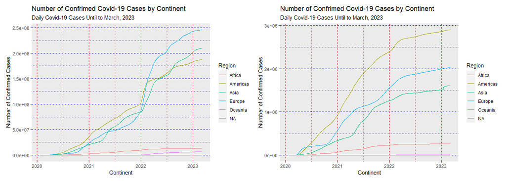

```r
# Step 3: Plot a histogram to compare total cases by Continent
global_by_region_chart_1 = ggplot(global_by_region, aes(x = Date, y = Total_Region_Cases, color = Region)) + geom_line() +
  labs(x = "Continent", y = "Number of Confirmed Cases",
       title = "Number of Confrimed Covid-19 Cases by Continent",
       subtitle = "Daily Covid-19 Cases Until to March, 2023") +
  theme(panel.grid.major = element_line(size = .5, linetype = "dashed"),
        panel.grid.minor = element_line(size = .25, linetype = "dotted"),
        panel.grid.major.x = element_line(color = "red1"),
        panel.grid.major.y = element_line(color = "blue1"),
        panel.grid.minor.x = element_line(color = "red4"),
        panel.grid.minor.y = element_line(color = "blue4"))
global_by_region_chart_2 = ggplot(global_by_region, aes(x = Date, y = Total_Region_Deaths, color = Region)) + geom_line() +
  labs(x = "Continent", y = "Number of Confirmed Cases",
       title = "Number of Confrimed Covid-19 Cases by Continent",
       subtitle = "Daily Covid-19 Cases Until to March, 2023") +
  theme(panel.grid.major = element_line(size = .5, linetype = "dashed"),
        panel.grid.minor = element_line(size = .25, linetype = "dotted"),
        panel.grid.major.x = element_line(color = "red1"),
        panel.grid.major.y = element_line(color = "blue1"),
        panel.grid.minor.x = element_line(color = "red4"),
        panel.grid.minor.y = element_line(color = "blue4"))

# The side by side charts require the patchwork library
global_by_region_chart_1 + global_by_region_chart_2
```

We can see from the above analysis that both the number of confirmed cases and deaths in Africa stayed lower than those in Americas, Europe and Asia from the start of the pandemic.

*Question 3:* Is there difference in number of confirmed cases of COVID-19 among African countries?

After establishing that COVID-19 cases and deaths were lower in Africa, let us review how cases and deaths differ among countries in Africa.

```r
# Step 4: Plot a line chart to compare total deaths by Continent
global_by_country_africa <- global_by_country %>% filter(Region == "Africa") %>% group_by(Country) %>% summarize(Total_Country_Cases = max(Total_Cases), Total_Country_Deaths = max(Total_Deaths)) %>% arrange(desc(Total_Country_Cases))

global_by_country_africa
```

```
## # A tibble: 56 x 3
##    Country      Total_Country_Cases Total_Country_Deaths
##    <chr>                      <dbl>                <dbl>
##  1 South Africa             4064889               102595
##  2 Morocco                  1272487                16296
##  3 Tunisia                  1150962                29331
##  4 Egypt                     515698                24809
##  5 Libya                     507174                 6437
##  6 Ethiopia                  500050                 7572
##  7 France                    494595                  921
##  8 Zambia                    343135                 4057
##  9 Kenya                     342919                 5688
## 10 Botswana                  329727                 2876
## # ... with 46 more rows
```

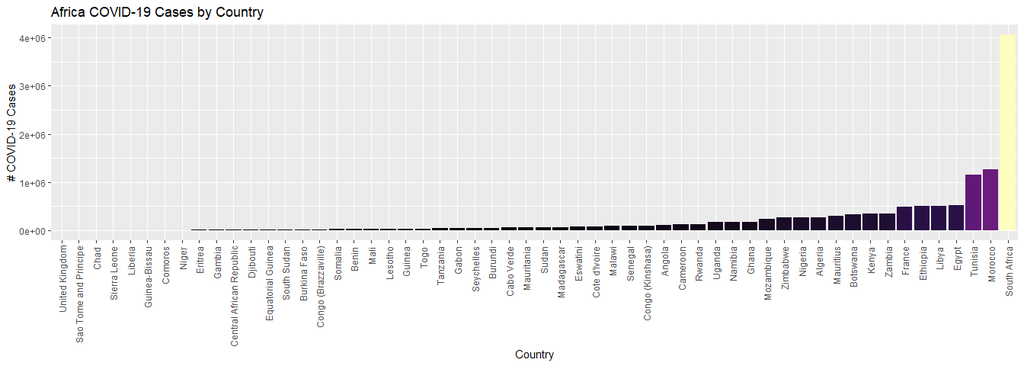

```r
# Step 5: Plot a histogram of cases and deaths for all countries
global_by_region_chart_3 <- ggplot(global_by_country_africa, aes(x = reorder(Country, +Total_Country_Cases),
  y = Total_Country_Cases,
  fill = Total_Country_Cases)) +
  scale_fill_viridis_c(option = "magma") +
  geom_bar(stat = "identity") +
  labs(x = "Country",
      y = "# COVID-19 Cases",
      title = "Africa COVID-19 Cases by Country") +
  theme(legend.position="none", axis.text.x=element_text(angle=90, hjust=.98, vjust = .5))


global_by_region_chart_4 <- ggplot(global_by_country_africa, aes(x = reorder(Country, +Total_Country_Deaths),
  y = Total_Country_Deaths,
  fill = Total_Country_Deaths)) +
  scale_fill_viridis_c(option = "magma") +
  geom_bar(stat = "identity") +
  labs(x = "Country",
      y = "# COVID-19 Deaths",
      title = "Africa COVID-19 Deaths by Country") +
  theme(legend.position="none", axis.text.x=element_text(angle=90, hjust=.98, vjust = .5))

global_by_region_chart_3
```

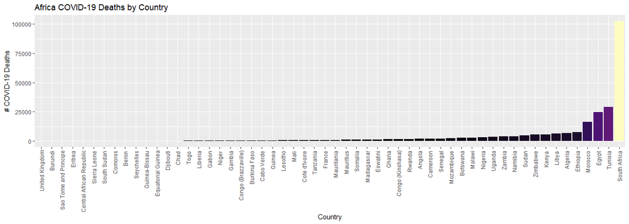

```r
global_by_region_chart_4
```

The above charts show that a few countries in Africa accounted for the highest confirmed cases and deaths due to COVID-19. Primarily, South Africa, Tunisia, Egypt, and Morocco are affected much more than other African countries.

### 4). MODEL

Given that countries in the World were affected differently by the COVID-19 pandemic, this model will assess if we can use population median age (or how relatively young a country’s population is) to predict the number of confirmed cases and deaths of COVID-19. For this model, a simple linear regression is used to assess if there is a statistically significant relationship between a country’s median age and the number of confirmed cases/deaths a country reports.

```r
global_by_country_with_age <- global %>% group_by(Region, Country) %>% summarize(Total_Cases = max(Cases), Total_Deaths = max(Deaths), Median_Age = max(Median_Age)) %>% arrange(desc(Total_Cases))

head(global_by_country_with_age)
```

```
## # A tibble: 6 x 5
## # Groups:   Region [3]
##   Region   Country Total_Cases Total_Deaths Median_Age
##   <chr>    <chr>         <dbl>        <dbl>      <dbl>
## 1 Americas US        103646940      1122164       37.5
## 2 Asia     India      44689327       530775       27.3
## 3 Europe   France     38591184       161407       41.4
## 4 Europe   Germany    38210851       168397       44.9
## 5 Americas Brazil     37081209       699276       32.4
## 6 Asia     Japan      33282370        72779       48
```

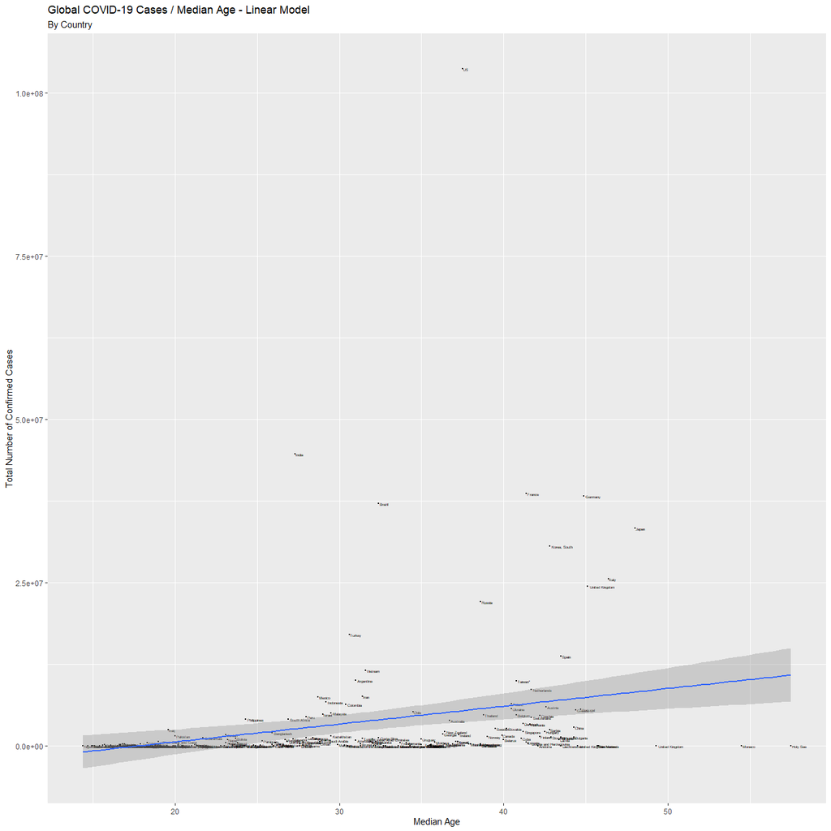

```r
ggplot(global_by_country_with_age , aes(x = Median_Age, y = Total_Cases, label = Country)) +
    geom_point(size = .4) +
    geom_text(size = 1.7, vjust = .5, hjust = -.1) +
    geom_smooth(method = "lm") +
    labs(x = "Median Age",
         y = "Total Number of Confirmed Cases",
         title = "Global COVID-19 Cases / Median Age - Linear Model",
         subtitle = "By Country")
```

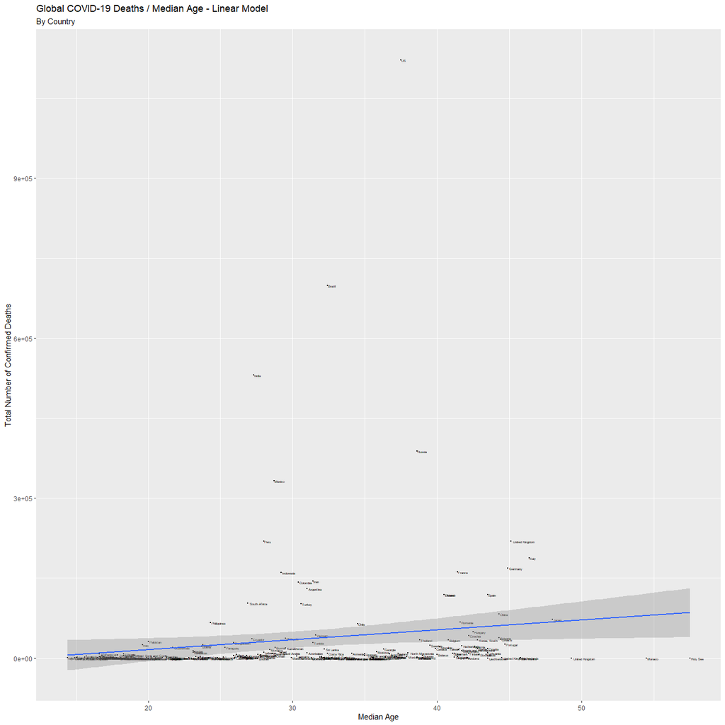

```r
ggplot(global_by_country_with_age , aes(x = Median_Age, y = Total_Deaths, label = Country)) +
    geom_point(size = .4) +
    geom_text(size = 1.7, vjust = .5, hjust = -.1) +
    geom_smooth(method = "lm") +
    labs(x = "Median Age",
         y = "Total Number of Confirmed Deaths",
         title = "Global COVID-19 Deaths / Median Age - Linear Model",
         subtitle = "By Country")
```

As the regression graph above shows, although there are outliers such as India and Turkey, there is a positive relationship between how old a country’s population is (as evaluated by median age) and the number of covid cases and deaths a country has. The older a country’s population, the larger the number of cases and deaths.

Let us use the “lm” function and fit the above regression models to assess if there is a statistically significant relationship between a country’s median age and the number of confirmed cases/deaths a country

```r
mod_cases <- lm(Total_Cases ~ Median_Age, global_by_country_with_age)
mod_deaths <- lm(Total_Deaths ~ Median_Age, global_by_country_with_age)
summary(mod_cases)
```

```
##
## Call:
## lm(formula = Total_Cases ~ Median_Age, data = global_by_country_with_age)
##
## Residuals:
##       Min        1Q    Median        3Q       Max
## -10865029  -3648170  -1406306    206807  98240336
##
## Coefficients:
##             Estimate Std. Error t value Pr(>|t|)
## (Intercept) -4827996    2209305  -2.185 0.030034 *
## Median_Age    272923      70555   3.868 0.000148 ***
## ---
## Signif. codes:  0 '***' 0.001 '**' 0.01 '*' 0.05 '.' 0.1 ' ' 1
##
## Residual standard error: 9736000 on 199 degrees of freedom
##   (9 observations deleted due to missingness)
## Multiple R-squared:  0.06993,    Adjusted R-squared:  0.06526
## F-statistic: 14.96 on 1 and 199 DF,  p-value: 0.0001485
```

```r
summary(mod_deaths)
```

```
##
## Call:
## lm(formula = Total_Deaths ~ Median_Age, data = global_by_country_with_age)
##
## Residuals:
##     Min      1Q  Median      3Q     Max
##  -85203  -36481  -19022   -7440 1073981
##
## Coefficients:
##             Estimate Std. Error t value Pr(>|t|)
## (Intercept) -21230.4    24837.4  -0.855   0.3937
## Median_Age    1851.0      793.2   2.334   0.0206 *
## ---
## Signif. codes:  0 '***' 0.001 '**' 0.01 '*' 0.05 '.' 0.1 ' ' 1
##
## Residual standard error: 109400 on 199 degrees of freedom
##   (9 observations deleted due to missingness)
## Multiple R-squared:  0.02664,    Adjusted R-squared:  0.02175
## F-statistic: 5.446 on 1 and 199 DF,  p-value: 0.02061
```

Both the above summaries show that there is a statistically significant relationship between a country’s median age and the number of confirmed cases/deaths a country, as given by the P-values using a 0.05 significance level.

## Conclusion

This analysis shows that the impact of COVID-19 on the African continent was much lower than in the Americas, Europe, and Asia, as evidenced by the lower number of COVID-19 cases and deaths. Most experts agree the relatively young population of Africa was a significant factor in lowering the impact, which is supported by the simple regression model in this review that showed there is a statistically significant relationship between a country’s median age and the number of confirmed cases/deaths a country

## Potential Bias

There are potentially two biases in the report. The first is that although the analysis shows that the number of cases and deaths in Africa was lower than Americas, Europe, and Asia, there is an excellent chance that those continents would have a better recording and reporting platform for COVID-19 incidents compared to African countries. This might have underestimated the confirmed cases and deaths in Africa. Second, the simple regression model only considers median age as an independent variable, while multiple factors could account for the difference in the impact of COVID-19 among countries.

## Further questions to investigate resulting from the above analysis

1. Considering additional factors in the model and doing further analysis to understand the impact of the difference in these factors among countries on the number of cases/deaths (focusing on those countries with a higher number of cases/deaths such as the US, India, France, Turkey, etc.)